# Tutorial 11 - Correlation and simple linear regression

Author: Matthew J. Crossley

29 March, 2026

```r
# load libraries

library(data.table)
library(ggplot2)

# clean work space

rm(list = ls())

# init colorscheme

COL <- c("#2271B2", "#E69F00", "#D55E00")
names(COL) <- c("blue", "orange", "red")
theme_set(
  theme_minimal(base_size = 13) +
    theme(
      panel.grid.minor = element_blank(),
      strip.text = element_text(face = "bold"),
      legend.position = "bottom"
    )
)
update_geom_defaults("point", list(size = 2))
update_geom_defaults("line", list(linewidth = 0.8))
```

## Overview

Two of the most widely used tools for examining relationships between continuous variables are **correlation** and **simple linear regression**.

Correlation tells you how strongly two variables are linearly associated. Simple linear regression goes further by fitting a line that predicts one variable from another.

In this tutorial, you will work with a human Serial Reaction Time (SRT) dataset. The key idea is that you must first create **one independent summary row per participant** before running inferential analyses such as `cor.test()` and `lm()`.

## Part 1 - Introducing the data

Thirty adults completed a 15-day SRT task. On each day, they completed blocks from a predictable condition and a random condition. Sequence learning should lead to a growing response-time advantage for the predictable condition.

```r
d <- fread("data/human_srt_summary.csv")
str(d)
```

```
## Classes 'data.table' and 'data.frame':   1800 obs. of  7 variables:
##  $ sub_id       : int  1 1 1 1 1 1 1 1 1 1 ...
##  $ group        : chr  "young" "young" "young" "young" ...
##  $ day          : int  1 1 1 1 2 2 2 2 3 3 ...
##  $ block        : int  1 2 3 4 5 6 7 8 9 10 ...
##  $ sequence_type: chr  "predictable" "random" "predictable" "random" ...
##  $ mean_rt      : num  409 413 391 381 384 ...
##  $ prop_correct : num  0.954 0.881 0.899 0.973 0.998 ...
##  - attr(*, ".internal.selfref")=<externalptr>
```

```r
head(d)
```

```
##    sub_id  group   day block sequence_type mean_rt prop_correct
##     <int> <char> <int> <int>        <char>   <num>        <num>
## 1:      1  young     1     1   predictable  409.17       0.9539
## 2:      1  young     1     2        random  412.53       0.8807
## 3:      1  young     1     3   predictable  390.69       0.8987
## 4:      1  young     1     4        random  381.13       0.9730
## 5:      1  young     2     5   predictable  384.26       0.9983
## 6:      1  young     2     6        random  403.97       0.9310
```

Each row here is a block, not a participant. That means the raw dataset is not yet at the right level for correlation or regression.

First, aggregate to one value per participant per day and condition.

```r
d_day <- d[, .(mean_rt = mean(mean_rt)), .(sub_id, group, day, sequence_type)]
head(d_day)
```

```
##    sub_id  group   day sequence_type mean_rt
##     <int> <char> <int>        <char>   <num>
## 1:      1  young     1   predictable 399.930
## 2:      1  young     1        random 396.830
## 3:      1  young     2   predictable 372.545
## 4:      1  young     2        random 399.940
## 5:      1  young     3   predictable 365.050
## 6:      1  young     3        random 387.900
```

Next, reshape to wide format so each row gives predictable and random mean RT for a participant on a given day.

```r
d_wide <- dcast(
  d_day,
  sub_id + group + day ~ sequence_type,
  value.var = "mean_rt"
)

d_wide[, rt_advantage := random - predictable]
head(d_wide)
## Key: <sub_id, group, day>
##    sub_id  group   day predictable  random rt_advantage
##     <int> <char> <int>       <num>   <num>        <num>
## 1:      1  young     1     399.930 396.830       -3.100
## 2:      1  young     2     372.545 399.940       27.395
## 3:      1  young     3     365.050 387.900       22.850
## 4:      1  young     4     344.490 401.780       57.290
## 5:      1  young     5     325.080 381.830       56.750
## 6:      1  young     6     328.155 402.425       74.270
```

Now create one participant-level summary row. For each participant, compute:

- `baseline_predictable` - predictable RT on Day 1
- `final_predictable` - predictable RT on Day 15
- `improvement_rt` - how much faster the participant became from Day 1 to Day 15
- `mean_advantage` - the participant’s average random minus predictable RT

```r
d_sub <- d_wide[, .(
  baseline_predictable = predictable[day == 1],
  final_predictable    = predictable[day == 15],
  improvement_rt       = predictable[day == 1] - predictable[day == 15],
  mean_advantage       = mean(rt_advantage)
), by = .(sub_id, group)]

d_sub
## Key: <sub_id, group>
##     sub_id  group baseline_predictable final_predictable improvement_rt mean_advantage
##      <int> <char>                <num>             <num>          <num>          <num>
##  1:      1  young              399.930           303.965         95.965       71.07133
##  2:      2  young              443.505           371.300         72.205       43.01133
##  3:      3  young              454.285           332.665        121.620       88.77167
##  4:      4  young              390.200           271.890        118.310       80.26633
##  5:      5  young              426.510           279.485        147.025       85.37767
##  6:      6  young              449.960           357.060         92.900       50.51700
##  7:      7  young              392.775           333.730         59.045       49.93167
##  8:      8  young              403.910           263.760        140.150       92.74000
##  9:      9  young              381.245           318.760         62.485       62.46733
## 10:     10  young              417.945           346.925         71.020       54.44633
## 11:     11  young              485.445           348.550        136.895       80.81833
## 12:     12  young              394.975           285.245        109.730       90.46767
## 13:     13  young              440.365           307.020        133.345       95.65267
## 14:     14  young              473.235           331.785        141.450       95.13600
## 15:     15  young              412.685           307.970        104.715       67.33367
## 16:     16  older              522.980           458.275         64.705       76.25833
## 17:     17  older              617.525           537.320         80.205       64.38700
## 18:     18  older              610.785           536.530         74.255       42.23167
## 19:     19  older              558.700           456.315        102.385       56.84800
## 20:     20  older              559.900           455.775        104.125       70.65967
## 21:     21  older              553.085           470.135         82.950       47.35467
## 22:     22  older              558.700           469.035         89.665       65.65267
## 23:     23  older              624.075           539.745         84.330       46.80967
## 24:     24  older              625.835           549.225         76.610       49.92067
## 25:     25  older              483.150           430.585         52.565       47.92867
## 26:     26  older              487.795           434.380         53.415       61.19467
## 27:     27  older              554.960           531.410         23.550       22.36400
## 28:     28  older              612.415           509.825        102.590       68.59067
## 29:     29  older              680.000           625.330         54.670       38.79767
## 30:     30  older              517.485           455.660         61.825       78.02733
##     sub_id  group baseline_predictable final_predictable improvement_rt mean_advantage
```

At this point, each row is one participant. That is the correct unit of analysis for the correlation and regression below.

## Part 2 - Visualising the relationship

Before computing statistics, make a scatter plot.

[figure not shown]

Participant-level relationship between sequence advantage and improvement across training.

```r
ggplot(d_sub, aes(x = mean_advantage, y = improvement_rt, colour = group)) +
  geom_point(size = 2, alpha = 0.8) +
  labs(
    x = "Mean RT advantage (random - predictable, ms)",
    y = "Improvement from Day 1 to Day 15 (ms)",
    colour = "Group",
    title = "Do participants with larger sequence advantages improve more?"
  ) +
  scale_colour_manual(values = COL)
```

If the relationship is positive, participants with larger overall sequence advantages also tend to show larger improvements across training.

## Part 3 - Correlation

Pearson’s correlation coefficient `r` measures the strength and direction of the linear association between two continuous variables.

```r
cor.test(d_sub$mean_advantage, d_sub$improvement_rt)
```

```
##
##  Pearson's product-moment correlation
##
## data:  d_sub$mean_advantage and d_sub$improvement_rt
## t = 7.0434, df = 28, p-value = 1.162e-07
## alternative hypothesis: true correlation is not equal to 0
## 95 percent confidence interval:
##  0.6169511 0.9004244
## sample estimates:
##       cor
## 0.7995136
```

How to read the output:

- `r` tells you the direction and strength of the linear association
- the p-value tests the null hypothesis that the population correlation is zero
- the confidence interval gives a plausible range for the true population `r`

You can also look at the relationship separately within each group.

```r
d_sub[group == "young", cor(mean_advantage, improvement_rt)]
```

```
## [1] 0.870716
```

```r
d_sub[group == "older", cor(mean_advantage, improvement_rt)]
```

```
## [1] 0.5105794
```

These grouped values are useful descriptively, but keep your main interpretation focused on the participant-level analysis using all 30 independent participants.

## Part 4 - Simple linear regression

Correlation tells you whether two variables are related. Regression tells you how much the outcome changes for a one-unit increase in the predictor.

Here, fit a model predicting `improvement_rt` from `mean_advantage`.

```r
fit <- lm(improvement_rt ~ mean_advantage, data = d_sub)
summary(fit)
```

```
##
## Call:
## lm(formula = improvement_rt ~ mean_advantage, data = d_sub)
##
## Residuals:
##     Min      1Q  Median      3Q     Max
## -46.046 -10.665   4.011  12.432  29.471
##
## Coefficients:
##                Estimate Std. Error t value Pr(>|t|)
## (Intercept)       5.075     12.618   0.402    0.691
## mean_advantage    1.317      0.187   7.043 1.16e-07 ***
## ---
## Signif. codes:  0 '***' 0.001 '**' 0.01 '*' 0.05 '.' 0.1 ' ' 1
##
## Residual standard error: 19.09 on 28 degrees of freedom
## Multiple R-squared:  0.6392, Adjusted R-squared:  0.6263
## F-statistic: 49.61 on 1 and 28 DF,  p-value: 1.162e-07
```

Interpret the output like this:

- **Intercept** - predicted improvement when `mean_advantage = 0`
- **Slope** - expected change in improvement for each 1 ms increase in mean sequence advantage
- **R-squared** - the proportion of variance in improvement explained by the predictor
- **F-statistic and p-value** - whether the model fits better than an intercept-only model

Add the fitted line to the scatter plot.

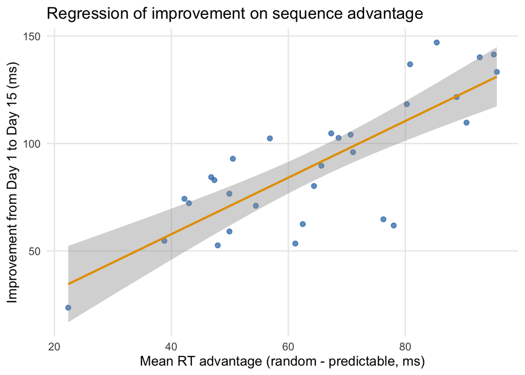

Participant-level regression line with 95% confidence band.

```r
ggplot(d_sub, aes(x = mean_advantage, y = improvement_rt)) +
  geom_point(alpha = 0.7, colour = COL[1]) +
  geom_smooth(method = "lm", se = TRUE, colour = COL[2]) +
  labs(
    x = "Mean RT advantage (random - predictable, ms)",
    y = "Improvement from Day 1 to Day 15 (ms)",
    title = "Regression of improvement on sequence advantage"
  )
```

## Part 5 - Regression diagnostics

Before interpreting a regression, inspect the residuals.

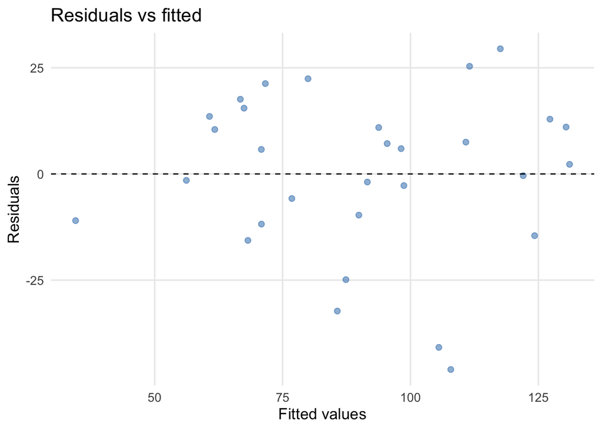

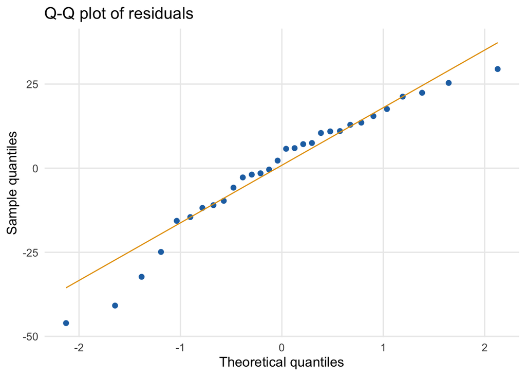

```r
d_diag <- data.table(fitted = fitted(fit), resid = resid(fit))

ggplot(d_diag, aes(x = fitted, y = resid)) +
  geom_point(colour = COL[1], alpha = 0.5) +
  geom_hline(yintercept = 0, linetype = "dashed") +
  labs(
    x = "Fitted values",
    y = "Residuals",
    title = "Residuals vs fitted"
  )

ggplot(d_diag, aes(sample = resid)) +
  stat_qq(colour = COL[1]) +
  stat_qq_line(colour = COL[2]) +
  labs(
    x = "Theoretical quantiles",
    y = "Sample quantiles",
    title = "Q-Q plot of residuals"
  )
```

Look for:

- residuals scattered around zero without a clear curve
- Q-Q points that stay reasonably close to the diagonal

## Part 6 - Comparing groups descriptively

You can also compare the two age groups on `mean_advantage`.

```r
d_sub[, .(
  n = .N,
  mean_advantage = mean(mean_advantage),
  sd_advantage = sd(mean_advantage)
), by = group]
```

```
##     group     n mean_advantage sd_advantage
##    <char> <int>          <num>        <num>
## 1:  young    15       73.86727     18.18650
## 2:  older    15       55.80169     15.44076
```

[figure not shown]

Mean sequence advantage by age group.

```r
ggplot(d_sub, aes(x = group, y = mean_advantage, fill = group)) +
  geom_boxplot(outlier.shape = NA) +
  geom_jitter(width = 0.12, alpha = 0.5) +
  scale_fill_manual(values = COL) +
  labs(
    x = "Group",
    y = "Mean RT advantage (ms)",
    fill = "Group",
    title = "Sequence advantage by age group"
  ) +
  theme(legend.position = "none")
```

This section is descriptive. The main worked examples for correlation and regression are the participant-level analyses above.

## Apply this to your assigned dataset

Your assigned dataset is determined by your student ID number. Take the last digit and compute `last_digit %% 3` in R.

- If the result is `0`: https://github.com/crossley/cogs2020/tree/main/final_project_data/cat_learn_switch
- If the result is `1`: https://github.com/crossley/cogs2020/tree/main/final_project_data/cat_learn_auto
- If the result is `2`: https://github.com/crossley/cogs2020/tree/main/final_project_data/cat_learn_unlearn

Load your assigned dataset and run a correlation and a simple regression. Specifically:

1. Identify two continuous variables that you expect to be related.
2. Make sure each row is an independent participant or unit before you analyse.
3. Create a scatter plot of those two variables.
4. Compute Pearson’s correlation with `cor.test()`.
5. Fit a simple linear regression with `lm()`.
6. Report the slope, intercept, R-squared, and p-value.
7. Check the residual plots.
8. Write a short paragraph interpreting the result in plain language.